# Real-data workflow: RPE1 Perturb-seq

# 1 Overview and scope

This tutorial runs CausalGRN on a prepared subset of the RPE1 Perturb-seq dataset. It shows one complete application workflow:

1. infer a causal gene regulatory network (GRN) that includes a transcriptional program node;
2. fit the perturbation-effect prediction model;
3. predict expression changes after setting three target genes to specified expression levels; and
4. evaluate how accurately the predictions rank held-out differentially expressed genes (DEGs).

The companion [manuscript-code repository](https://github.com/yub-hutch/CausalGRN-manuscript-code) provides the broader cross-validation and method-comparison analyses.

The example takes approximately 15 minutes with 10 CPU cores and used about 18 GB of memory in our test.

```r
# Run once if CausalGRN is not installed.
devtools::install_github("yub-hutch/CausalGRN")
```

```r
library(CausalGRN)
library(dplyr)
library(ggplot2)
library(igraph)
```

# 2 Prepare the RPE1 inputs

## 2.1 Data sources and preprocessing

The RPE1 data and the K562 source-context summaries originate from the [processed Perturb-seq data of Replogle and Weissman](https://doi.org/10.25452/figshare.plus.20029387). The HCT116 source-context summaries originate from [X-Atlas/Orion](https://doi.org/10.25452/figshare.plus.29190726.v1).

The deposited tutorial file provides processed inputs ready for CausalGRN. The Replogle release normalizes expression within experimental gem groups to address batch effects. Our subsequent preparation filters cells and genes and regresses dataset-specific technical covariates from normalized expression. In another dataset, the appropriate covariates may differ; the general requirement is to remove known technical and confounding effects, including batch effects, before CausalGRN analysis.

The [manuscript-code repository](https://github.com/yub-hutch/CausalGRN-manuscript-code) documents the dataset-specific regression models and complete processing steps. This tutorial starts from their prepared outputs and focuses on the executable CausalGRN workflow.

## 2.2 Gene-program input

RPE1 contains a dominant perturbation-response program. The companion preprocessing workflow identifies this program and defines its member genes. The deposited tutorial data provide the resulting program node and `program_genes` input.

For a new dataset, users should inspect the perturbation responses for influential programs. When a program is present, define its member genes and include it in the network with the gene-program functions used below. When no influential program is present, use `infer_skeleton()`, `infer_causalgrn()`, `fit_expression_model()`, and `predict_perturbation_effect()` as shown in the quick-start tutorial.

## 2.3 Reference source effects

When reference Perturb-seq datasets are available, first score their cells using the same program definition as the target dataset. For source dataset $s$ and perturbation $g$, summarize the source effect as

$$\Delta_{s,g} =
\operatorname{mean}(\text{program score}\mid \text{perturbation }g) -
\operatorname{mean}(\text{program score}\mid \text{WT}).$$

Each source is supplied as a data frame with a `ko` column and one numeric effect column named after that source. The `source_effects` input is a named list of these data frames. The [manuscript-code repository](https://github.com/yub-hutch/CausalGRN-manuscript-code) provides the complete program-scoring and source-effect preparation scripts.

## 2.4 Download and inspect the tutorial data

The file is hosted in the public [CausalGRN tutorial-data project](https://osf.io/zu7dn/). The checksum prevents the workflow from silently using a different file.

```r
data_url <- "https://osf.io/download/6a66cab03059ac3f76135bfb/"
data_file <- file.path("data", "rpe1-tutorial-data.rds")
expected_md5 <- "aa57b50b5885cf21d713f8ce3bf5130e"

if (!file.exists(data_file)) {
  dir.create(dirname(data_file), recursive = TRUE, showWarnings = FALSE)
  download.file(
    url = data_url,
    destfile = data_file,
    mode = "wb"
  )
}

actual_md5 <- unname(tools::md5sum(data_file))
stopifnot(identical(actual_md5, expected_md5))

tutorial_data <- readRDS(data_file)
```

The object is a named list:

- `count`: prepared cell-by-node counts used for skeleton inference;
- `Y`: adjusted cell-by-node expression, including the program score;
- `group`: one perturbation label per cell, with `"WT"` denoting the reference cells;
- `program_genes`: member genes of the transcriptional program;
- `source_effects`: K562 and HCT116 effects on the RPE1-defined program score, used to model how program effects transfer across contexts; and
- `heldout_deg`: observed DEG labels reserved for evaluating the three prediction targets.

```r
count <- tutorial_data$count
Y <- tutorial_data$Y
group <- tutorial_data$group
program_genes <- tutorial_data$program_genes
source_effects <- tutorial_data$source_effects
heldout_deg <- tutorial_data$heldout_deg

targets <- c("GPS1", "SRP72", "SRSF7")
program_name <- "PC1"
ncores <- 10L

stopifnot(
  identical(dim(count), dim(Y)),
  identical(rownames(count), names(group)),
  identical(rownames(Y), names(group)),
  identical(colnames(count), colnames(Y)),
  all(program_genes %in% colnames(Y)),
  all(targets %in% colnames(Y)),
  !any(group %in% targets),
  identical(rownames(heldout_deg), targets),
  identical(colnames(heldout_deg), setdiff(colnames(Y), program_name)),
  is.logical(heldout_deg),
  all(rowSums(heldout_deg) > 0)
)

data.frame(
  cells = nrow(Y),
  nodes = ncol(Y),
  perturbation_groups = length(unique(group)),
  WT_cells = sum(group == "WT"),
  program_genes = length(program_genes)
)
```

```
#>   cells nodes perturbation_groups WT_cells program_genes
#> 1 87472   268                 265    11485            14
```

Network inference and model fitting use WT cells and perturbations other than the three prediction targets. The observed RPE1 outcomes for these targets are reserved for the evaluation in the final section.

# 3 Infer the causal GRN

## 3.1 Infer the graph skeleton

`infer_skeleton_with_gene_program()` tests marginal and order-one conditional independence among the input nodes. The arguments used here are:

- `count = count`: raw counts used by the sparsity-aware conditional- independence tests;
- `Y = Y`: adjusted expression used to calculate correlations and partial correlations;
- `alpha = 0.05`: the significance threshold for the conditional-independence tests;
- `min_abspcor = 0.02`: the minimum absolute partial correlation required to retain an edge;
- `pname = program_name`: the name of the program node;
- `pgenes = program_genes`: the member genes that must be connected to the program node in the skeleton; and
- `ncores = ncores`: the number of CPU cores used in parallel calculations.

The function returns the skeleton as an `igraph` object.

```r
skeleton <- infer_skeleton_with_gene_program(
  count = count,
  Y = Y,
  alpha = 0.05,
  min_abspcor = 0.02,
  pname = program_name,
  pgenes = program_genes,
  ncores = ncores
)

data.frame(
  nodes = igraph::vcount(skeleton),
  edge_entries = igraph::ecount(skeleton)
)
```

```
#>   nodes edge_entries
#> 1   268          532
```

## 3.2 Estimate observed perturbation effects

`calc_perturbation_effect()` compares each observed perturbation group with WT for every node:

- `Y = Y` supplies the adjusted expression values;
- `group = group` identifies the WT and perturbed cells and is aligned with the rows of `Y`; and
- `ncores = ncores` controls parallel calculation.

The returned table reports the WT-to-perturbation mean difference (`diff`), Cohen’s d (`cd`), test results, and adjusted p-values for every perturbation-node pair. `adj_pv` is the larger of the adjusted Wilcoxon and t-test p-values and is used for graph orientation.

```r
perturbation_stat <- calc_perturbation_effect(
  Y = Y,
  group = group,
  ncores = ncores
)

head(
  perturbation_stat[, c("ko", "gene", "diff", "cd", "adj_pv")]
)
```

```
#> # A tibble: 6 × 5
#>   ko    gene        diff       cd    adj_pv
#>   <chr> <chr>      <dbl>    <dbl>     <dbl>
#> 1 ACTB  ABCF1    0.142    0.143   2.28e-  1
#> 2 ACTB  ACTB    -3.28    -3.30    2.92e-147
#> 3 ACTB  ACTR1B  -0.00521 -0.00522 9.82e-  1
#> 4 ACTB  ADAM10  -0.0701  -0.0706  9.40e-  1
#> 5 ACTB  ANKRD11  0.0318   0.0321  8.53e-  1
#> 6 ACTB  ANKS6    0.0242   0.0243  9.00e-  1
```

## 3.3 Orient the skeleton

`infer_causalgrn_with_gene_program()` uses significant observed perturbation effects to direct the skeleton:

- `graph = skeleton` supplies the graph to orient;
- `stat = perturbation_stat` supplies the observed effects;
- `alpha = 0.05` is the significance threshold applied to `stat$adj_pv`;
- `pname = program_name` and `pgenes = program_genes` identify the program node and its member genes; and
- `conservative = TRUE` retains both possible directions unless the perturbation evidence supports one direction.

The function returns an `igraph` object. A single `from`-to-`to` row is an oriented edge; reciprocal rows indicate that the direction remains unresolved.

```r
causal_graph <- infer_causalgrn_with_gene_program(
  graph = skeleton,
  stat = perturbation_stat,
  alpha = 0.05,
  pname = program_name,
  pgenes = program_genes,
  conservative = TRUE
)

data.frame(
  nodes = igraph::vcount(causal_graph),
  edge_entries = igraph::ecount(causal_graph)
)
```

```
#>   nodes edge_entries
#> 1   268          390
```

```r
edge_table <- igraph::as_data_frame(causal_graph, what = "edges")
edge_table <- edge_table[
  order(edge_table$from, edge_table$to),
  c("from", "to", "absPcorMin")
]
knitr::kable(head(edge_table, 10), digits = 3)
```

|  | from | to | absPcorMin |
| --- | --- | --- | --- |
| 1 | ABCF1 | PC1 | 0.103 |
| 4 | ACTB | PC1 | 0.022 |
| 2 | ACTB | TUBA1B | 0.099 |
| 3 | ACTB | TUBB | 0.093 |
| 5 | ACTR1B | PC1 | 0.032 |
| 6 | ADAM10 | PC1 | 0.035 |
| 7 | ANKS6 | PC1 | 0.050 |
| 9 | AP2M1 | PC1 | 0.080 |
| 8 | AP2M1 | PKM | 0.070 |
| 10 | ARL2 | PC1 | 0.042 |

# 4 Fit the perturbation-effect models

## 4.1 Fit using reference source effects

`fit_expression_model_with_gene_program()` fits two linked model components:

1. one linear expression model per node, using its incoming GRN neighbors as predictors and cells in which that modeled node is unperturbed; and
2. portability regressions that relate source-context effects on the RPE1-defined program to its observed RPE1 effects across perturbations available during fitting.

Its arguments are:

- `Y = Y`, `group = group`, and `graph = causal_graph`: the RPE1 expression, perturbation labels, and inferred GRN;
- `source_effects = source_effects`: the prepared K562 and HCT116 effects on the RPE1-defined program score;
- `pname = program_name` and `pgenes = program_genes`: the program definition;
- `ncores = ncores`: the number of CPU cores used to fit node-level models; and
- `alpha = 0.1`: the F-test significance threshold for accepting a portability regression.

The result contains `B_matrix`, whose rows are predictors and columns are modeled nodes, and `portability_models`, which are used to predict the RPE1 program-node effect for a new perturbation.

```r
expression_model <- fit_expression_model_with_gene_program(
  Y = Y,
  group = group,
  graph = causal_graph,
  source_effects = source_effects,
  pname = program_name,
  pgenes = program_genes,
  ncores = ncores,
  alpha = 0.1
)

data.frame(
  coefficient_rows = nrow(expression_model$B_matrix),
  modeled_nodes = ncol(expression_model$B_matrix)
)
```

```
#>   coefficient_rows modeled_nodes
#> 1              269           268
```

## 4.2 Fit when reference source effects are unavailable

When the target dataset contains an influential program but suitable reference source effects are unavailable, `fit_expression_model()` can fit the same program-containing graph directly from the target dataset. `Y = Y`, `group = group`, and `graph = causal_graph` supply the adjusted expression, perturbation labels, and inferred graph; `ncores = ncores` controls parallel model fitting. The function returns the regulatory coefficient matrix.

```r
expression_model_without_source <- fit_expression_model(
  Y = Y,
  group = group,
  graph = causal_graph,
  ncores = ncores
)

dim(expression_model_without_source)
```

```
#> [1] 269 268
```

# 5 Predict effects at specified intervention expression levels

## 5.1 Specify the intervention levels

An **intervention expression level** is the value imposed on a target gene for prediction: “What expression changes would follow if this gene were set to this level?” Users choose this input before observing the downstream response.

For illustration, each target is set to the first percentile of its expression among the RPE1 WT cells. Users can replace these values with other experimentally meaningful levels.

```r
wt_expressions <- colMeans(Y[group == "WT", , drop = FALSE])

intervention_expressions <- vapply(
  targets,
  function(target) {
    unname(stats::quantile(
      Y[group == "WT", target],
      probs = 0.01
    ))
  },
  FUN.VALUE = numeric(1)
)

knitr::kable(
  data.frame(
    target = targets,
    WT_mean = unname(wt_expressions[targets]),
    intervention_expression_level = unname(intervention_expressions)
  ),
  digits = 3
)
```

| target | WT_mean | intervention_expression_level |
| --- | --- | --- |
| GPS1 | 0.030 | -0.993 |
| SRP72 | 0.102 | -1.582 |
| SRSF7 | 0.223 | -1.431 |

## 5.2 Predict using reference source effects

`predict_perturbation_effect_with_gene_program()` first converts each specified target level to a change from its WT mean, predicts the accompanying RPE1 program-node change from the reference source effects, and propagates those known changes through the fitted RPE1 model.

- `B = expression_model$B_matrix` supplies the fitted regulatory coefficients;
- `portability_models = expression_model$portability_models` supplies the fitted cross-context program-effect models;
- `source_effects = source_effects` supplies the K562 and HCT116 program effects for the prediction targets;
- `ko_expressions = intervention_expressions` supplies the specified target expression levels;
- `wt_expressions = wt_expressions` supplies the RPE1 WT reference means; and
- `pname = program_name` and `pgenes = program_genes` supply the program definition.

The returned matrix contains predicted expression changes from WT, with one target per row and one modeled node per column.

```r
predicted_effects <- predict_perturbation_effect_with_gene_program(
  B = expression_model$B_matrix,
  portability_models = expression_model$portability_models,
  source_effects = source_effects,
  ko_expressions = intervention_expressions,
  wt_expressions = wt_expressions,
  pname = program_name,
  pgenes = program_genes
)

dim(predicted_effects)
```

```
#> [1]   3 268
```

## 5.3 Predict without reference source effects

`predict_perturbation_effect()` uses the target-dataset coefficient matrix to propagate each specified intervention through the inferred graph, including the program node. `B = expression_model_without_source` supplies the fitted coefficients, `ko_expressions = intervention_expressions` supplies the specified target levels, and `wt_expressions = wt_expressions` supplies the WT reference means.

```r
predicted_effects_without_source <- predict_perturbation_effect(
  B = expression_model_without_source,
  ko_expressions = intervention_expressions,
  wt_expressions = wt_expressions
)

dim(predicted_effects_without_source)
```

```
#> [1]   3 268
```

## 5.4 Inspect the strongest predicted effects

The figure reports the five strongest predicted decreases and increases among individual downstream genes for each intervention target.

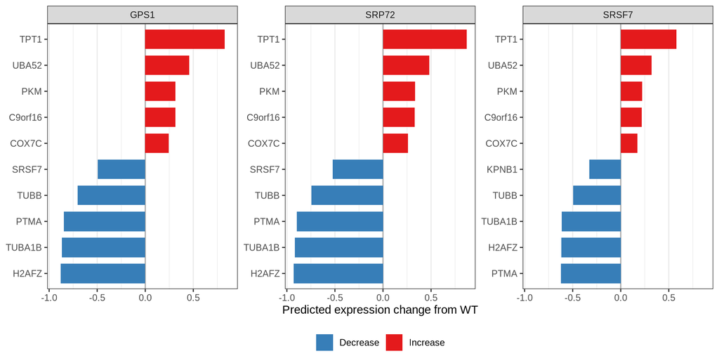

Five strongest predicted decreases and increases for each intervention target.

```r
prediction_table <- as.data.frame(
  as.table(predicted_effects),
  responseName = "predicted_change"
)
names(prediction_table)[1:2] <- c("target", "gene")
prediction_table$target <- as.character(prediction_table$target)
prediction_table$gene <- as.character(prediction_table$gene)
prediction_table <- prediction_table[
  prediction_table$gene != program_name &
    prediction_table$gene != prediction_table$target,
]

strongest_decreases <- prediction_table |>
  group_by(target) |>
  slice_min(
    order_by = predicted_change,
    n = 5,
    with_ties = FALSE
  ) |>
  mutate(direction = "Decrease")

strongest_increases <- prediction_table |>
  group_by(target) |>
  slice_max(
    order_by = predicted_change,
    n = 5,
    with_ties = FALSE
  ) |>
  mutate(direction = "Increase")

strongest_effects <- bind_rows(
  strongest_decreases,
  strongest_increases
) |>
  ungroup() |>
  arrange(target, predicted_change)

strongest_effects$plot_label <- factor(
  paste(strongest_effects$target, strongest_effects$gene, sep = "___"),
  levels = unique(
    paste(strongest_effects$target, strongest_effects$gene, sep = "___")
  )
)

ggplot(
  strongest_effects,
  aes(
    x = predicted_change,
    y = plot_label,
    fill = direction
  )
) +
  geom_vline(xintercept = 0, color = "grey60", linewidth = 0.4) +
  geom_col(width = 0.75) +
  facet_wrap(~target, scales = "free_y") +
  scale_y_discrete(labels = function(x) sub(".*___", "", x)) +
  scale_fill_manual(
    values = c("Decrease" = "#377EB8", "Increase" = "#E41A1C")
  ) +
  labs(
    x = "Predicted expression change from WT",
    y = NULL,
    fill = NULL
  ) +
  theme_bw() +
  theme(
    legend.position = "bottom",
    panel.grid.major.y = element_blank()
  )
```

# 6 Evaluate held-out DEG ranking

The full RPE1 dataset supplies observed differential-expression labels for GPS1, SRP72, and SRSF7. A gene is labeled as a DEG when `calc_perturbation_effect()` applied to the full dataset gives `adj_pv < 0.05`. These labels are used here after model fitting.

For each target, genes are ranked by the absolute predicted expression change from the source-aware model. Each curve shows the proportion of held-out DEGs among the top $N$ ranked genes. The dashed line gives the DEG prevalence expected under random ranking. Each curve extends through the observed number of DEGs for that target.

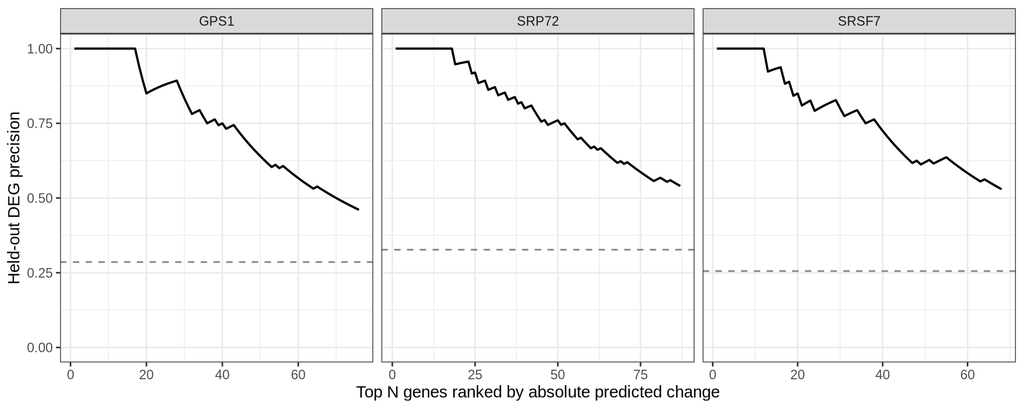

Precision of held-out DEG recovery as genes are ranked by absolute predicted expression change. Dashed lines show DEG prevalence.

```r
precision_curves <- do.call(
  rbind,
  lapply(targets, function(target) {
    genes <- setdiff(
      intersect(colnames(predicted_effects), colnames(heldout_deg)),
      target
    )
    ranked_genes <- genes[
      order(abs(predicted_effects[target, genes]), decreasing = TRUE)
    ]
    is_deg <- heldout_deg[target, ranked_genes]
    top_n <- seq_len(sum(is_deg))

    data.frame(
      target = target,
      top_n = top_n,
      precision = cumsum(is_deg)[top_n] / top_n,
      DEG_prevalence = mean(is_deg)
    )
  })
)

precision_baselines <- unique(
  precision_curves[, c("target", "DEG_prevalence")]
)

ggplot(
  precision_curves,
  aes(x = top_n, y = precision)
) +
  geom_hline(
    data = precision_baselines,
    aes(yintercept = DEG_prevalence),
    linetype = "dashed",
    color = "grey50"
  ) +
  geom_line(linewidth = 0.7) +
  facet_wrap(~target, nrow = 1, scales = "free_x") +
  coord_cartesian(ylim = c(0, 1)) +
  labs(
    x = "Top N genes ranked by absolute predicted change",
    y = "Held-out DEG precision"
  ) +
  theme_bw()
```

The [manuscript-code repository](https://github.com/yub-hutch/CausalGRN-manuscript-code) provides the dataset-wide cross-validation analysis.